# General Linear Madness

Fernando Miguez

9/29/2020

# Intro

The first example is about Geometric people. This is an excuse to revisit models in which the relationship among parameters is not necessarily linear. One of the main benefits is that these models can be constructed following theoretical concepts and thus, the parameters have meaningful interpretations. There are somethings to keep in mind:

- Parameters need to be **identifiable**. If this is not obviously mathematically, it will be when you try to fit the model. The parameters will be correlated to a high degree or the model will not converge. In the HMC context, you will get divergence or other small ESS or something else.
- You might have competing models which are very reasonable *a priori* and will need to fit them and compare them using WAIC or other criteria.
- You can assign priors for these type of models based on previous data or experience. You do not have to always scale variables as it is done in the book

## Simple example using an asymptotic regression model

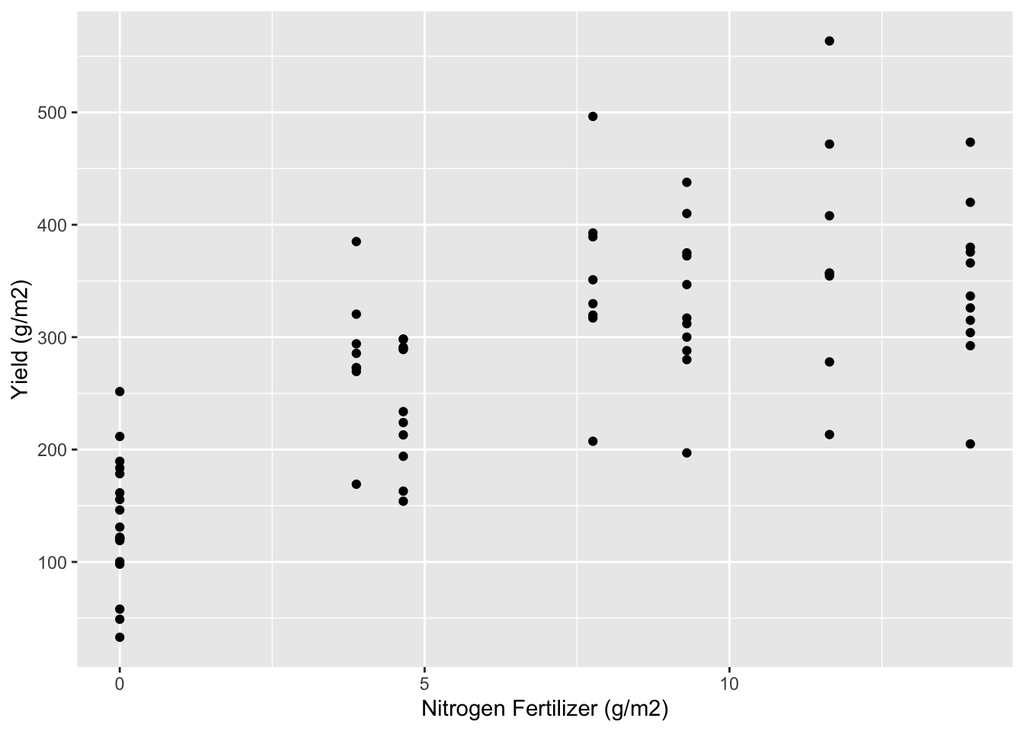

```r
data(barley, package = "nlraa")

## Visualize
ggplot(data = barley, aes(x = NF, y = yield)) +
  geom_point() + ylab("Yield (g/m2)") + xlab("Nitrogen Fertilizer (g/m2)")
```

```r
priors <- prior(normal(400, 100), nlpar = "Asym", coef = "Intercept") +
  prior(normal(-2, 2), nlpar = "lrc", coef = "Intercept") +
  prior(normal(100, 50), nlpar = "R0", coef = "Intercept")

bf1 <- bf(yield ~ Asym + (R0 - Asym)*exp(-exp(lrc) * NF),
           Asym + R0 + lrc ~ 1,
           nl = TRUE)

brm1 <- brm(bf1, data = barley, seed = 123, prior = priors, refresh = 0)
### Output
brm1
```

```
##  Family: gaussian
##   Links: mu = identity; sigma = identity
## Formula: yield ~ Asym + (R0 - Asym) * exp(-exp(lrc) * NF)
##          Asym ~ 1
##          R0 ~ 1
##          lrc ~ 1
##    Data: barley (Number of observations: 76)
## Samples: 4 chains, each with iter = 2000; warmup = 1000; thin = 1;
##          total post-warmup samples = 4000
##
## Population-Level Effects:
##                Estimate Est.Error l-95% CI u-95% CI Rhat Bulk_ESS Tail_ESS
## Asym_Intercept   395.89     41.24   337.24   497.41 1.00     1614     1017
## R0_Intercept     132.33     15.69   102.00   163.19 1.00     2414     2153
## lrc_Intercept     -1.78      0.36    -2.52    -1.10 1.00     1538      993
##
## Family Specific Parameters:
##       Estimate Est.Error l-95% CI u-95% CI Rhat Bulk_ESS Tail_ESS
## sigma    72.26      6.23    61.65    86.16 1.00     2727     2030
##
## Samples were drawn using sampling(NUTS). For each parameter, Bulk_ESS
## and Tail_ESS are effective sample size measures, and Rhat is the potential
## scale reduction factor on split chains (at convergence, Rhat = 1).
```

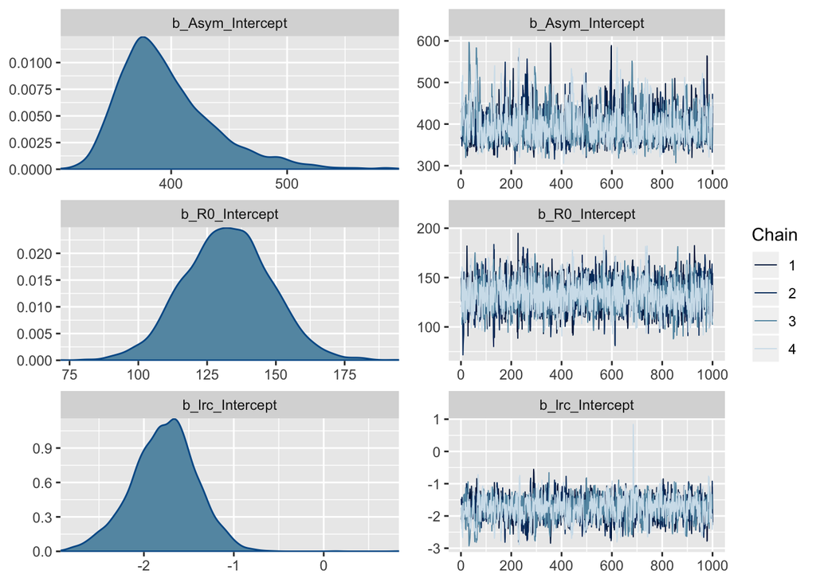

```r
## Visualize results
plot(brm1, "^b_")
```

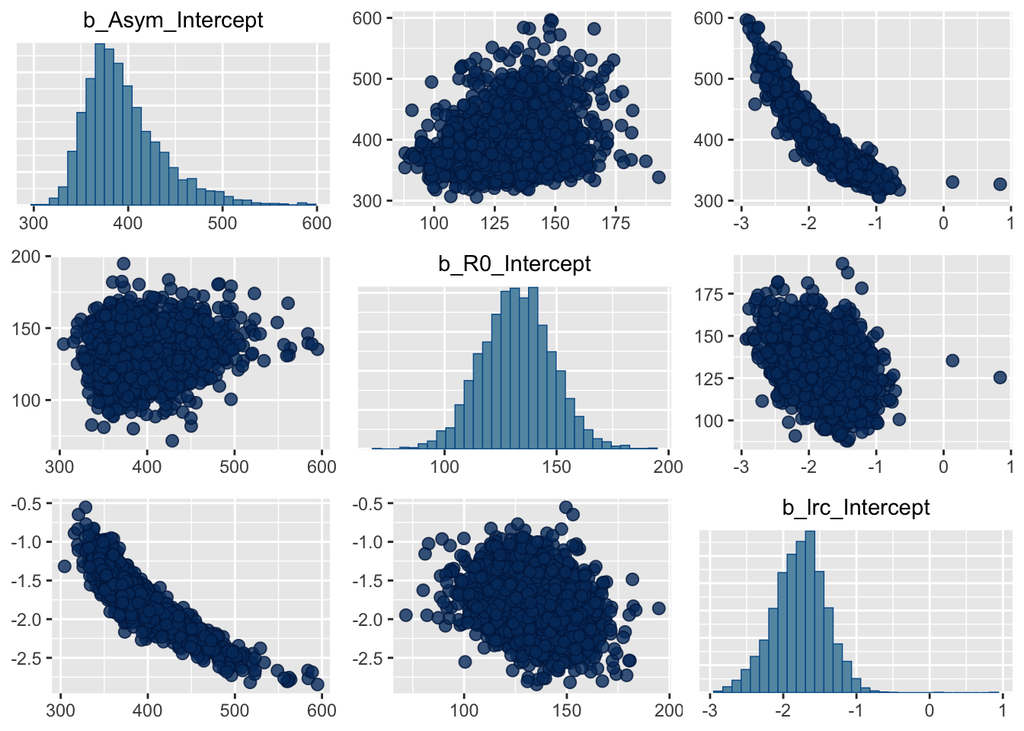

```r
## Pairs plot
pairs(brm1, "^b_")
```

```r
## Can we get the correlation matrix for this plot?
round(cov2cor(vcov(brm1)), 2)
```

```
##                Asym_Intercept R0_Intercept lrc_Intercept
## Asym_Intercept           1.00         0.17         -0.90
## R0_Intercept             0.17         1.00         -0.31
## lrc_Intercept           -0.90        -0.31          1.00
```

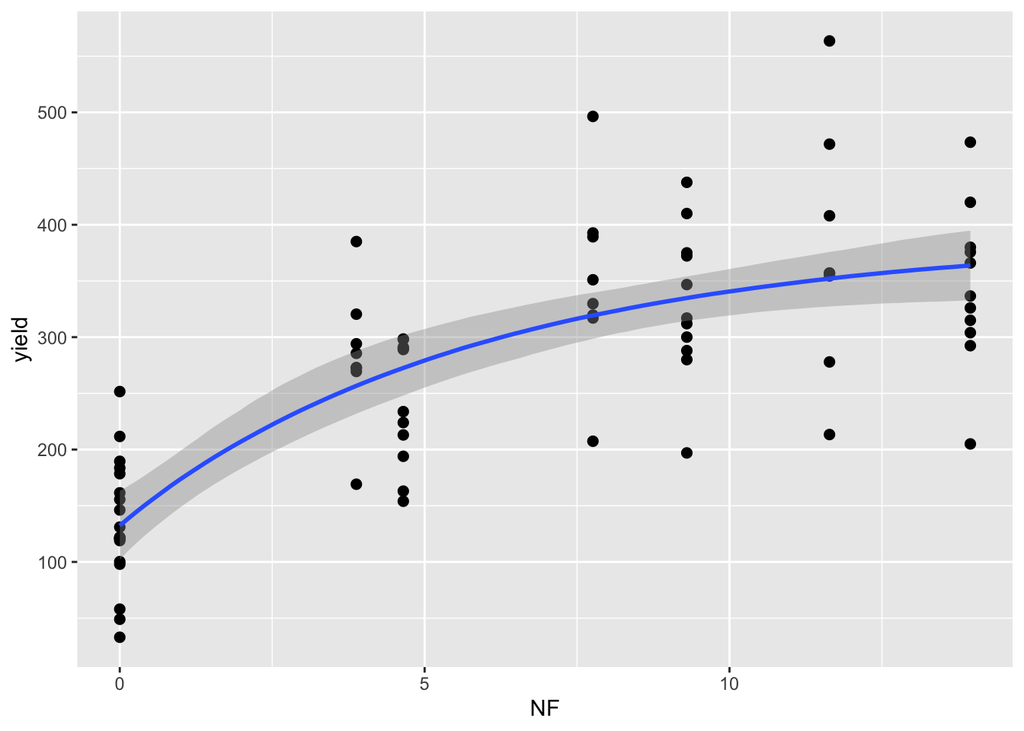

```r
## Plot conditinal effects
plot(conditional_effects(brm1), points = TRUE)
```

```r
## How do I just extract the parameter estimates?
prm.est <- fixef(brm1)
round(prm.est, 1)
```

```
##                Estimate Est.Error  Q2.5 Q97.5
## Asym_Intercept    395.9      41.2 337.2 497.4
## R0_Intercept      132.3      15.7 102.0 163.2
## lrc_Intercept      -1.8       0.4  -2.5  -1.1
```

```r
## There is a Bayes R^2, which I guess it means something??
bayes_R2(brm1)
```

```
##     Estimate  Est.Error      Q2.5    Q97.5
## R2 0.6023969 0.04468204 0.5016564 0.672277
```

```r
## Compute the WAIC and LOO
waic(brm1)
```

```
##
## Computed from 4000 by 76 log-likelihood matrix
##
##           Estimate   SE
## elpd_waic   -434.4  7.1
## p_waic         3.7  0.8
## waic         868.9 14.1
##
## 1 (1.3%) p_waic estimates greater than 0.4. We recommend trying loo instead.
```

```r
loo(brm1)
```

```
##
## Computed from 4000 by 76 log-likelihood matrix
##
##          Estimate   SE
## elpd_loo   -434.5  7.1
## p_loo         3.7  0.8
## looic       868.9 14.2
## ------
## Monte Carlo SE of elpd_loo is 0.0.
##
## All Pareto k estimates are good (k < 0.5).
## See help('pareto-k-diagnostic') for details.
```